# MB590 Microbiome Analysis

Christine V. Hawkes

3/30/2022

# Analyzing Factorial Designs with Permutation Procedures

```
References:

Collyer & Adams (2018) RRPP: An r package for fitting linear models to high‐dimensional data using residual randomization. Methods in Ecology and Evolution 9: 1772-1779. DOI: 10.1111/2041-210X.13029

Bolker et al. (2009) Generalized linear mixed models: a practical guide for ecology and evolution. TREE 24: 127-135. DOI: 10.1016/j.tree.2008.10.008

Data:

Erlandson et al. (2018) Soil abiotic variables are more important than Salicaceae phylogeny or habitat specialization in determining soil microbial community structure. Molecular Ecology 27:2007-2024 DOI: 10.1111/mec.14576
DRYAD entry: https://datadryad.org/stash/dataset/doi:10.5061/dryad.5f24ks4
```

# Libraries and Data

## Install and load R libraries

```r
#install.packages("RRPP")

library(tidyverse); packageVersion("tidyverse")
```

```
## [1] '1.3.1'
```

```r
library(phyloseq); packageVersion("phyloseq")
```

```
## [1] '1.38.0'
```

```r
library(DESeq2); packageVersion("DESeq2")
```

```
## [1] '1.34.0'
```

```r
library(RRPP); packageVersion("RRPP")
```

```
## [1] '1.1.2'
```

```r
library(vegan); packageVersion("vegan")
```

```
## [1] '2.5.7'
```

```r
library(ggplot2); packageVersion("ggplot2")
```

```
## [1] '3.3.5'
```

```r
library(ggordiplots); packageVersion("ggordiplots")
```

```
## [1] '0.4.0'
```

## Load and prepare data

- Data from Erlandson et al. 2018 that we have used previously
- All files are on GitHub, add the raw url path to the read commands
- Or, if you saved the RData as suggested last week, you can open your own file

```r
# load data
load("wk12_data.RData")
ps_vst
```

```
## phyloseq-class experiment-level object
## otu_table()   OTU Table:         [ 6758 taxa and 215 samples ]
## sample_data() Sample Data:       [ 215 samples by 41 sample variables ]
## tax_table()   Taxonomy Table:    [ 6758 taxa by 7 taxonomic ranks ]
```

```r
# check that "Observed" is in your sample_data from last week's richness calcs
colnames(phyloseq::sample_data(ps_vst))
```

```
##  [1] "GardenID"           "Garden.Location"    "Number"
##  [4] "Treatment"          "June"               "July"
##  [7] "Aug"                "Mean"               "Nmin"
## [10] "NO3"                "NH4"                "pH"
## [13] "Spp"                "Ecology"            "Sample"
## [16] "Genotype"           "Caged.E..Not.Caged" "Plant_Height_m"
## [19] "Date_Sampled"       "extraction_date"    "Lat"
## [22] "Long"               "Plot"               "Dist1"
## [25] "Dist2"              "Dist3"              "order"
## [28] "TLP"                "WD"                 "SPI"
## [31] "LSV"                "RER"                "SLA"
## [34] "RGR"                "TLP.F"              "WD.F"
## [37] "SPI.F"              "SLA.F"              "Axis.1"
## [40] "Axis.2"             "Observed"
```

```r
# useful functions to pull sample and otu files from the ps object in the correct formats
# phyloseq to dataframe
ps2df_sam <- function(physeq) {
  sd <- phyloseq::sample_data(physeq)
  return(as(sd,"data.frame"))
}

# phyloseq to matrix
ps2m_otu <- function(physeq) {
  OTU <- phyloseq::otu_table(physeq)
  if(phyloseq::taxa_are_rows(OTU)) {
    OTU <- t(OTU)
  }
  return(as(OTU, "matrix"))
}

# get data using above functions
SAM <- ps2df_sam(ps_vst)
OTU <- ps2m_otu(ps_vst)

# confirm that the two files have the same rownames
all(rownames(SAM)==rownames(OTU))
```

```
## [1] TRUE
```

# Factorial analysis of alpha diversity

## Check assumptions

```r
# we'll use the non-parametric RRPP because some assumptions are violated

# test null hyp that sample comes from a normal distribution
# slightly off from normal
# note that sqrt transform from orig paper makes it worse!
shapiro.test((SAM$Observed))
```

```
##
##  Shapiro-Wilk normality test
##
## data:  (SAM$Observed)
## W = 0.98329, p-value = 0.01204
```

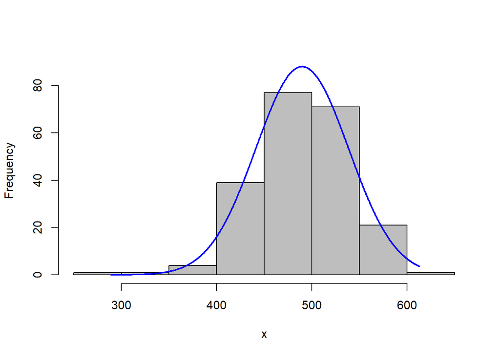

```r
rcompanion::plotNormalHistogram(SAM$Observed)
```

```r
# test null hyp of no difference in variance across groups
# homogeneous variances except for Plot
bartlett.test(Observed ~Treatment, data=SAM)
```

```
##
##  Bartlett test of homogeneity of variances
##
## data:  Observed by Treatment
## Bartlett's K-squared = 0.03395, df = 1, p-value = 0.8538
```

```r
bartlett.test(Observed ~Spp, data=SAM)
```

```
##
##  Bartlett test of homogeneity of variances
##
## data:  Observed by Spp
## Bartlett's K-squared = 14.871, df = 13, p-value = 0.3155
```

```r
bartlett.test(Observed ~Plot, data=SAM)
```

```
##
##  Bartlett test of homogeneity of variances
##
## data:  Observed by Plot
## Bartlett's K-squared = 26.409, df = 12, p-value = 0.009391
```

## permANOVA - richness

**RRPP - richness fixed effects model**

```r
# define dependent var
rich <- SAM$Observed

# fixed factor only - ignores random terms
# with this model, Treatment has a significant effect on richness
rich.rrpp <- RRPP::lm.rrpp(rich ~ Treatment,
                   data = SAM, SS.type="III",
                   print.progress = FALSE, iter=1000)
anova(rich.rrpp, effect.type = "F")
```

```
##
## Analysis of Variance, using Residual Randomization
## Permutation procedure: Randomization of null model residuals
## Number of permutations: 1001
## Estimation method: Ordinary Least Squares
## Sums of Squares and Cross-products: Type III
## Effect sizes (Z) based on F distributions
##
##            Df     SS      MS     Rsq      F      Z   Pr(>F)
## Treatment   1  30587 30587.4 0.06014 13.629 3.0473 0.000999 ***
## Residuals 213 478024  2244.2 0.93986
## Total     214 508611
## ---
## Signif. codes:  0 '***' 0.001 '**' 0.01 '*' 0.05 '.' 0.1 ' ' 1
##
## Call: RRPP::lm.rrpp(f1 = rich ~ Treatment, iter = 1000, SS.type = "III",
##     data = SAM, print.progress = FALSE)
```

**RRPP - richness mixed model**

```r
# orig paper used Spp and Plot as a random effects
# plot here does not include interaction given replication issues
# rerun RRPP as mixed model with both
# sig spatial effect of Plot and only a trend for Treatment
rich.rrpp2 <- RRPP::lm.rrpp(rich ~ Treatment*Spp+Plot,
                   data = SAM, SS.type="III",
                   print.progress = FALSE, iter=1000)
```

```
##
## Warning: Because variables in the linear model are redundant,
## the linear model design has been truncated (via QR decomposition).
## Original X columns: 29
## Final X columns (rank): 28
## Check coefficients or degrees of freedom in ANOVA to see changes.
```

```r
# if you don't specify the MS error terms, model will use Residuals
anova(rich.rrpp2, effect.type = "F")
```

```
##
## Analysis of Variance, using Residual Randomization
## Permutation procedure: Randomization of null model residuals
## Number of permutations: 1001
## Estimation method: Ordinary Least Squares
## Sums of Squares and Cross-products: Type III
## Effect sizes (Z) based on F distributions
##
##                Df     SS    MS     Rsq       F       Z   Pr(>F)
## Treatment       1   3444  3444 0.00677  1.6361  0.8313 0.218781
## Spp            13  21254  1635 0.04179  0.7766 -0.5073 0.691309
## Plot            1  54296 54296 0.10675 25.7904  3.6303 0.000999 ***
## Treatment:Spp  12  10446   871 0.02054  0.4135 -1.7091 0.958042
## Residuals     187 393687  2105 0.77404
## Total         214 508611
## ---
## Signif. codes:  0 '***' 0.001 '**' 0.01 '*' 0.05 '.' 0.1 ' ' 1
##
## Call: RRPP::lm.rrpp(f1 = rich ~ Treatment * Spp + Plot, iter = 1000,
##     SS.type = "III", data = SAM, print.progress = FALSE)
```

```r
# to get correct F ratios, specify MS error terms
# check order from model output
anova(rich.rrpp2, effect.type = "F",
      error = c("Treatment:Spp", "Residuals", "Residuals", "Residuals"))
```

```
##
## Analysis of Variance, using Residual Randomization
## Permutation procedure: Randomization of null model residuals
## Number of permutations: 1001
## Estimation method: Ordinary Least Squares
## Sums of Squares and Cross-products: Type III
## Effect sizes (Z) based on F distributions
##
##                Df     SS    MS     Rsq       F       Z   Pr(>F)
## Treatment       1   3444  3444 0.00677  3.9567  1.5709 0.051948 .
## Spp            13  21254  1635 0.04179  0.7766 -0.5073 0.691309
## Plot            1  54296 54296 0.10675 25.7904  3.6303 0.000999 ***
## Treatment:Spp  12  10446   871 0.02054  0.4135 -1.7091 0.958042
## Residuals     187 393687  2105 0.77404
## Total         214 508611
## ---
## Signif. codes:  0 '***' 0.001 '**' 0.01 '*' 0.05 '.' 0.1 ' ' 1
##
## Call: RRPP::lm.rrpp(f1 = rich ~ Treatment * Spp + Plot, iter = 1000,
##     SS.type = "III", data = SAM, print.progress = FALSE)
```

**Plot richness data for interpretation**

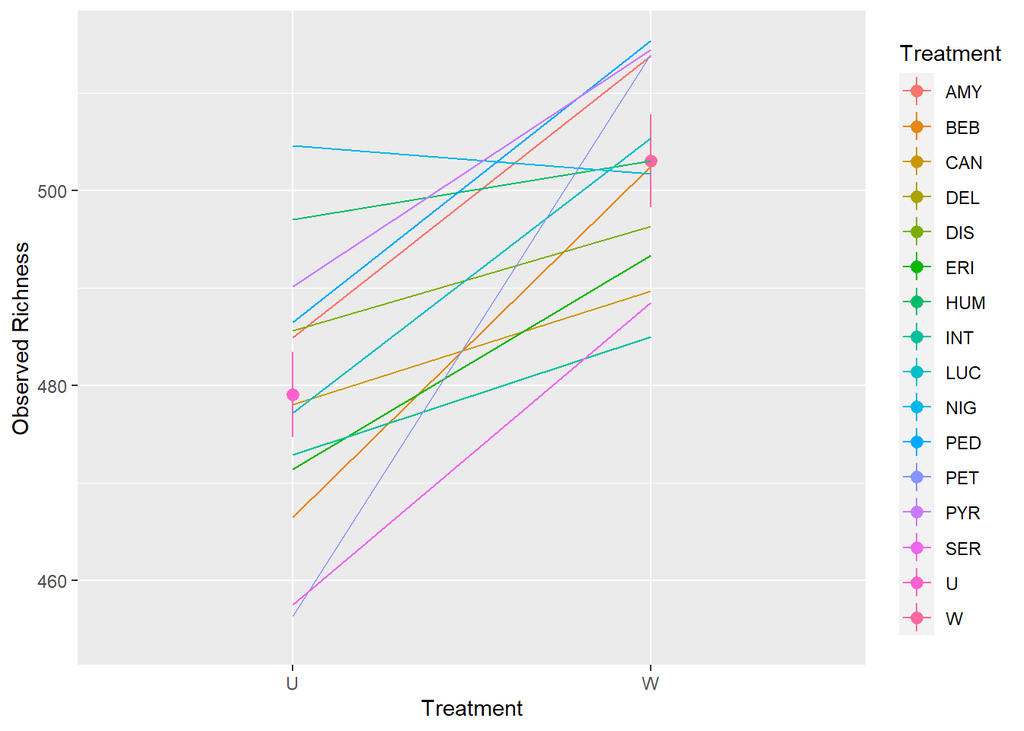

```r
 # use a reaction norm plot to view how Spp range between Trtmt gardens
 ggplot2::ggplot(SAM, ggplot2::aes(x=Treatment, y=rich, color=Treatment)) +
   ggplot2::stat_summary(fun.data="mean_se", geom="pointrange") +
   ggplot2::stat_summary(ggplot2::aes(group = Spp, color=Spp), fun = "mean", geom = "path") +
   ggplot2::ylab("Observed Richness")
```

# Factorial analysis of beta diversity

## PermANOVA - beta diversity

```r
# Note: can use mvnormtest::mshapiro.test for multivariate Shapiro-Wilks
# but only works for <5000 OTUs

# OLS
# For real data, typically use iter=1000
# But for class reduced to iter=50 because it can take a while to run

otu.rrpp <- RRPP::lm.rrpp(OTU ~ Treatment*Spp+Plot,
                   data = SAM, SS.type="III",
                   print.progress = FALSE,
                   seed="random",
                   iter=50)
```

```
##
## Warning: Because variables in the linear model are redundant,
## the linear model design has been truncated (via QR decomposition).
## Original X columns: 29
## Final X columns (rank): 28
## Check coefficients or degrees of freedom in ANOVA to see changes.
```

```r
anova(otu.rrpp, effect.type = "F",
      error = c("Treatment:Spp", "Residuals", "Residuals", "Residuals"))
```

```
##
## Analysis of Variance, using Residual Randomization
## Permutation procedure: Randomization of null model residuals
## Number of permutations: 51
## Estimation method: Ordinary Least Squares
## Sums of Squares and Cross-products: Type III
## Effect sizes (Z) based on F distributions
##
##                Df     SS     MS     Rsq      F       Z  Pr(>F)
## Treatment       1   3376 3375.9 0.00872 1.8138  3.4833 0.01961 *
## Spp            13  21174 1628.8 0.05467 0.9573 -1.0272 0.84314
## Plot            1   6802 6802.0 0.01756 3.9977  6.5445 0.01961 *
## Treatment:Spp  12  22335 1861.3 0.05766 1.0939  2.2324 0.01961 *
## Residuals     187 318178 1701.5 0.82146
## Total         214 387335
## ---
## Signif. codes:  0 '***' 0.001 '**' 0.01 '*' 0.05 '.' 0.1 ' ' 1
##
## Call: RRPP::lm.rrpp(f1 = OTU ~ Treatment * Spp + Plot, iter = 50, seed = "random",
##     SS.type = "III", data = SAM, print.progress = FALSE)
```

```r
# you can run rrpp with GLS if you include a covariance matrix (Cov = )

# note that rrpp::manova.update will also provide Pillai's Trace and Roy's largest root
# but current version cannot handle mixed models (i.e., will only use MS Residual error term)
# future version will allow specification of error term - see manual
```

## PermANOVA - beta diversity distance matrix

**Calculate distance matrix and check assumptions**

```r
# get distance matrix
OTU_d <- vegan::vegdist(OTU, method="euclidean")

# test multivariate homogeneity of variances (dispersions)
# alt is to use vegan::permutest(betadisp) instead of anova
# heterogeneous variances for Treatment and Plot
# but difference is minimized compared to other distances
# and permutational approach should be robust to this
anova(vegan::betadisper(OTU_d, SAM$Treatment))
```

```
## Analysis of Variance Table
##
## Response: Distances
##            Df  Sum Sq Mean Sq F value  Pr(>F)
## Groups      1   328.6  328.55  4.7031 0.03122 *
## Residuals 213 14880.1   69.86
## ---
## Signif. codes:  0 '***' 0.001 '**' 0.01 '*' 0.05 '.' 0.1 ' ' 1
```

```r
anova(vegan::betadisper(OTU_d, SAM$Spp))
```

```
## Analysis of Variance Table
##
## Response: Distances
##            Df  Sum Sq Mean Sq F value Pr(>F)
## Groups     13   726.7  55.903  0.7074 0.7549
## Residuals 201 15884.4  79.027
```

```r
anova(vegan::betadisper(OTU_d, SAM$Plot))
```

```
## Analysis of Variance Table
##
## Response: Distances
##            Df Sum Sq Mean Sq F value    Pr(>F)
## Groups     12 4533.4  377.78  7.7076 1.007e-11 ***
## Residuals 202 9900.9   49.01
## ---
## Signif. codes:  0 '***' 0.001 '**' 0.01 '*' 0.05 '.' 0.1 ' ' 1
```

**RRPP**

```r
# run RRPP on euclidean distance matrix - are results the same?
otu.rrpp.d <- RRPP::lm.rrpp(OTU_d ~ Treatment*Spp+Plot,
                   data = SAM, SS.type="III",
                   print.progress = FALSE,
                   seed="random",
                   iter=50)
```

```
##
## Warning: Because variables in the linear model are redundant,
## the linear model design has been truncated (via QR decomposition).
## Original X columns: 29
## Final X columns (rank): 28
## Check coefficients or degrees of freedom in ANOVA to see changes.
```

```r
anova(otu.rrpp.d, effect.type = "F",
      error = c("Treatment:Spp", "Residuals", "Residuals", "Residuals"))
```

```
##
## Analysis of Variance, using Residual Randomization
## Permutation procedure: Randomization of null model residuals
## Number of permutations: 51
## Estimation method: Ordinary Least Squares
## Sums of Squares and Cross-products: Type III
## Effect sizes (Z) based on F distributions
##
##                Df     SS     MS     Rsq      F       Z  Pr(>F)
## Treatment       1   3376 3375.9 0.00872 1.8138  2.8002 0.01961 *
## Spp            13  21174 1628.8 0.05467 0.9573 -1.1560 0.92157
## Plot            1   6802 6802.0 0.01756 3.9977  3.4023 0.01961 *
## Treatment:Spp  12  22335 1861.3 0.05766 1.0939  1.7271 0.05882 .
## Residuals     187 318178 1701.5 0.82146
## Total         214 387335
## ---
## Signif. codes:  0 '***' 0.001 '**' 0.01 '*' 0.05 '.' 0.1 ' ' 1
##
## Call: RRPP::lm.rrpp(f1 = OTU_d ~ Treatment * Spp + Plot, iter = 50,
##     seed = "random", SS.type = "III", data = SAM, print.progress = FALSE)
```

**Visualize with PCoA ord scores on vst-transformed data**

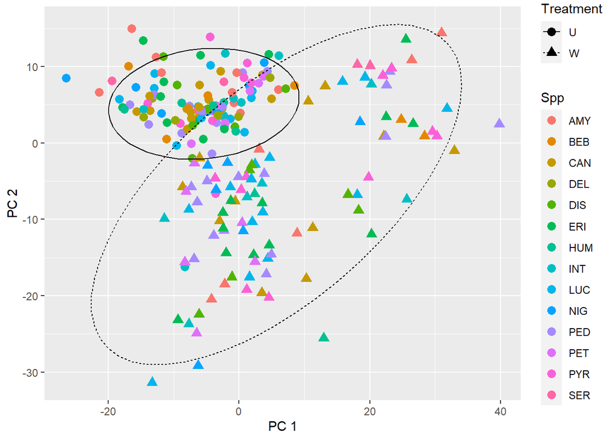

```r
ggplot(data = SAM, aes(x = Axis.1, y = Axis.2, color = Spp, shape = Treatment)) +
      geom_point(size = 3) + xlab("PC 1") + ylab("PC 2") +
      stat_ellipse(data=SAM, aes(x=Axis.1, y=Axis.2, lty=Treatment), inherit.aes=FALSE)
```

# Coding Exercises

**1. Rerun PermANOVA on non-euclidean distance matrix**

- Start with the otu matrix (already vst transformed)
- Select a distance metric such as Bray Curtis, Jaccard, etc.
- Rerun RRPP - how does this compare to earlier results?
- Visualize with ordination

**2. Build a new permANOVA model**

- Use data from Wagner et al. 2016 - import these files from GitHub:
  - “Wk12_Wagner_SAM.csv”
  - “Wk12_Wagner_ASV.csv”
- Original data were reduced as follows:
  - limited to samples in 2011 (phyloseq::subset_samples)
  - limited to the ecotype experiment (phyloseq::subset_samples)
  - removed one site with fewer blocks (phyloseq::subset_samples)
  - removed unidentified taxa (phyloseq::subset_taxa)
  - removed taxa with less than 20 reads (phyloseq::prune_taxa)
  - if your computer is slow, consider removing taxa <50 reads
- For this coding exercise:
  - Transform the data with clr or vst (your choice)
  - Examine the experimental factors in the SAM_data file
  - Use original paper to understand fixed vs. random effects
    - https://www.nature.com/articles/ncomms12151
  - Define a simplified factorial design
    - Simplified design is to allow for faster calculation of permutations
    - Include two fixed effects
    - Include one random effect
    - Include interactions with random effects (may have to specify entire model)
  - Run a permANOVA based on your design using RRPP
    - Check that the F ratios were calculated correctly
    - Use RRPP::pairwise for posthoc tests for significant factors
      - Limit to those with >2 treatment levels
  - Visualize results with an ordination
  - Interpret the results

**3. Test number of permutations**

- Create a simplified fixed effects model from the Wagner et al. data
  - Use two fixed effects (ignore random effects for simplicity)
- Run RRPP permANOVA with increasing permutations (e.g., iter=10, 100, 1000)
- Describe how the number of permutations changes model results